# 1 度数分析

#### 仮説

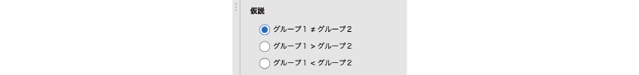

(#fig:frequencies-chisq-statistics-hypothesis)仮説の設定項目

- グループ1 ≠ グループ2 グループ1と2で比率が異なるかどうかを検定します（両側検定）
- グループ1 > グループ2 グループ1の比率がグループ2より大きいかどうかを検定します（片側検定）
- グループ1 < グループ2 グループ1の比率がグループ2より小さいかどうかを検定します（片側検定）

この設定項目が結果に影響するのは，「比率の差のz検定」にチェックが入っている場合のみです。なお，片側検定を使用する際には，結果の「$\chi^2$検定」の表の下にある注釈で，比較の向きが正しいかどうかをよく確認してください。また，この「**仮説**」の右側にある「比較方法」の部分を「行」に設定すると行ごとの比率の差の検定，「列」にすると列ごとの比率の差の検定になります。

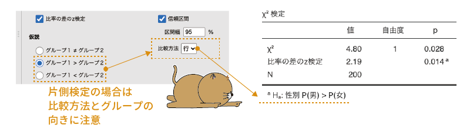

(#fig:frequencies-chisq-hypothesis)片側検定の場合は比較の向きに注意

#### 比較指標（2行2列の場合のみ）

ここに含まれている設定項目は，2行2列（2×2）のクロス集計表の場合のみ有効なものです。

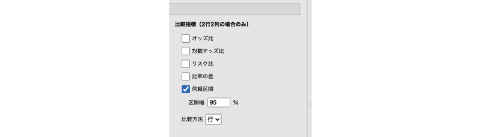

(#fig:frequencies-chisq-comparative)2行2列のクロス集計表における比較指標

- オッズ比
- 対数オッズ比
- リスク比
- 比率の差
- 信頼区間
- 比較方法

ここでは，オッズや比率を2つのグループ間で比較する際に用いられる指標の設定を行いますが，その際，行での比較を行うか，列での比較を行うかは，各指標の下にある「比較方法」で設定します。

この「比較方法」を「行」に設定すると，オッズや比率が行ごとに算出され，それらの間で比較が行われます。先ほどのイヌ派とネコ派のクロス集計表でいうと，男性におけるイヌ派の比率と，女性におけるイヌ派の比率の間で比較が行われます（図@ref(fig:frequencies-chisq-compare-setting)）。

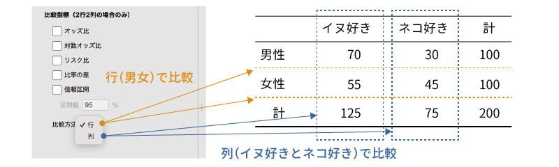

(#fig:frequencies-chisq-compare-setting)比較方法の設定

これに対して，「比較方法」を「列」に設定すると，ネコ派における男女比と，イヌ派における男女比の間での比較になります。この「比較方法」の設定は，「比率の差のz検定」にも反映されます。

では，ここで設定できる各種指標について簡単にみておきましょう。

##### オッズ比

「あり・なし」や「はい・いいえ」などの2値変数において，「あり」である確率と「なし」である確率の比をとったものを*オッズ*と呼びます。先ほどの「イヌ派」と「ネコ派」の例でいえば，「イヌ派率」と「ネコ派率」を「イヌ派率/ネコ派率」の形で表したものが「イヌ派のオッズ」です。

そして，さらにそのオッズ2種類を比の形にして表したものが*オッズ比*です。先ほどの例では，男性ではイヌ派のオッズは「0.7/0.3 = 2.33」，女性ではイヌ派のオッズは「0.55/0.45 = 1.22」ですので，イヌ派についての男女のオッズ比は「2.33/1.22 = 1.91」となります。

##### 対数オッズ比

2つの確率の比であるオッズは，2つの確率のうちの小さな値を基準（分母）におくか，大きな値を基準におくかで値のとりうる範囲が大きく異なります。たとえば，男性のイヌ派のオッズは「70/30 = 2.33」ですが，これは男性の場合，イヌ派である確率の方がネコ派である確率の2.33倍であることを意味します。このように小さい方の値を基準とした場合には，オッズは1から無限大までの範囲をとりうる値になります。

これに対し，男性のネコ派のオッズは「0.3/0.7 = 0.43」で，これはネコ派の確率がイヌ派の確率の0.43倍であるということになるのですが，このように大きい方の値を基準としてオッズを算出した場合，オッズの値は0から1までの範囲にしかなりません。

また，イヌ派のオッズとネコ派のオッズは，0.7/0.3と0.3/0.7というように分数の上下を入れ替えただけの違いであるのに，その値は2.33と0.43というようにまったく異なる数値になっていて，とくに関連があるようには見えません。

ところが，これらのオッズを対数変換すると，「log(0.7/0.3) = 0.85」，「log(0.3/0.7) = $-\textsf{0.85}$」となって，両者が方向を逆転させた関係にあることがわかりやすくなります。また，この場合には，プラスの値は0から無限大まで，マイナスの値もマイナス無限大の値をとることができるようになるのです。このように，オッズを用いる場合には，それを対数変換した方が関係を理解しやすくなることが多いのです。

これはオッズ比の場合も同様で，そしてオッズ比を対数に変換したものが*対数オッズ比*です。先ほどの例の，イヌ派についての男女のオッズ比を対数オッズ比に直すと，「log 1.91 = 0.65」になります。

##### リスク比

オッズ比が2グループのオッズの比であるのに対して，2グループの確率をそのまま比の形で表したものが*リスク比*です。先ほどのイヌ派・ネコ派の例でいうと，イヌ派の割合は男性では0.7（70%），女性では0.55（55%）ですので，「0.7/0.55 = 1.27」というのがイヌ派についての男女のリスク比ということになります。

##### 比率の差

これは，2つのグループにおける比率の差です。「**検定**」の設定項目にある「比率の差のz検定」は，この2グループの比率の差をzに変換して検定を行っています。

イヌ派・ネコ派の例では，イヌ派の割合は男性で0.7，女性で0.55ですので，比率の差の値は「$\textsf{0.7}-\textsf{0.55} = \textsf{0.15}$」になります。

ここまでの指標の関係をまとめると図@ref(fig:frequencies-chisq-comparative-measures)のようになります。

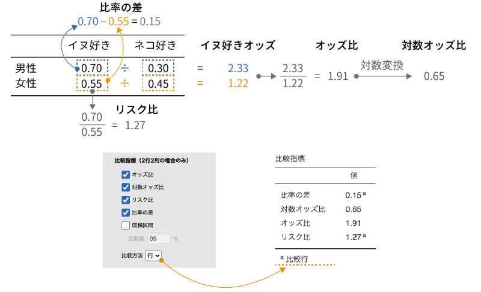

(#fig:frequencies-chisq-comparative-measures)比較指標の関係と一覧

##### 信頼区間

「信頼区間」の項目にチェックを入れると，オッズ比や対数オッズ比，リスク比などの各指標について，指定した幅の信頼区間が算出されます。

#### 名義尺度

「**名義尺度**」では，分析対象のデータが名義型変数（

[figure not shown]

）である場合の**連関係数**に関する設定を行います。連関係数とは，クロス集計表における行の要素と列の要素の間の関連の強さを表す指標のことです。

ここには，次の2つの設定項目が含まれています（図@ref(fig:frequencies-chisq-contingency)）。

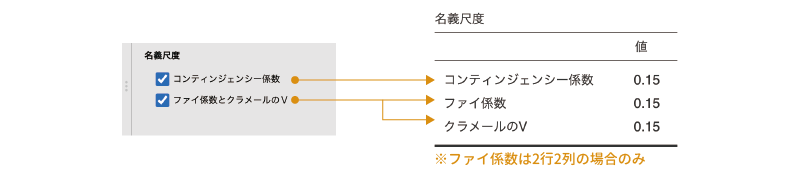

(#fig:frequencies-chisq-contingency)名義尺度の連関係数

- コンティンジェンシー係数
- ファイ係数とクラメールのV

##### コンティンジェンシー係数

*コンティンジェンシー係数*は，$\chi^2$の値を「$\chi^2$+総度数」で割った値の平方根で，これはクロス集計表の行要素と列要素の関連の強さを示します。この値は*ピアソンの連関係数C*とも呼ばれます。この値は，行と列の連関が0である（行と列が独立である）場合に0となり，連関が強いほど1に近い値になります。

##### ファイ係数とクラメールのV

この項目にチェックを入れると，*ファイ係数*と*クラメールの連関係数V*の2種類の値が算出されます。

ファイ（$\varphi$）係数と呼ばれるものには，$\chi^2$の値を総度数で割ったものの平方根として求められるものと，ピアソンの積率相関係数を2行2列のクロス集計表に適用したもの（これは*四分点相関係数*とも呼ばれます）の2種類が存在しますが，jamoviで算出されるのは後者です。このファイ係数は，2行2列のクロス集計表でのみ算出されます。

これらの値も，コンティンジェンシー係数と同様に，行と列の連関が0である（行と列が独立である）場合に0となり，連関が強いほど1に近い値になります。

#### 順序尺度

「**順序尺度**」では，分析対象のデータが順序型変数（

[figure not shown]

）である場合の関連度指標に関する設定を行います。

ここには，次の3つの項目が含まれています（図@ref(fig:frequencies-chisq-ordinal)）。

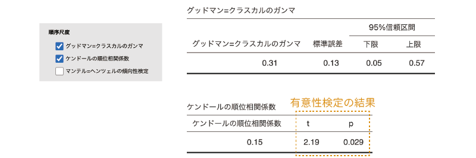

(#fig:frequencies-chisq-ordinal)順序尺度の関連度

- グッドマン=クラスカルのガンマ
- ケンドールの順位相関係数
- マンテル=ヘンツェルの傾向性検定

##### グッドマン=クラスカルのガンマ

*グッドマン=クラスカルのガンマ*は，順位相関係数の一種です。2行2列のクロス集計表の場合には，このガンマの値は*ユールのQ*と呼ばれることもあります。グッドマン=クラスカルのガンマは，スピアマンの順位相関係数などと同様に$-\textsf{1}$から1までの範囲をとります。

この設定は，クロス集計表の行と列の両方が順序型変数である場合に有効です。それ以外の場合にも計算結果は表示されますが，それらの値は適切ではない可能性があります。

##### ケンドールの順位相関係数

この項目にチェックを入れると，ケンドールの順位相関係数が算出されます。

この設定は，クロス集計表の行と列の両方が順序型変数である場合に有効です。それ以外の場合にも計算結果は表示されますが，それらの値は適切ではない可能性があります。

##### マンテル=ヘンツェルの傾向性検定

*マンテル=ヘンツェルの傾向性検定*は，行数または列数が2で，もう一方が順序型変数である場合のクロス集計表に使用可能な検定です。

たとえば表@ref(tab:frequencies-chisq-feature-table)のようなクロス集計表があったとします。この表には，行方向にはある特徴のあり・なしが，列方向には学年が置かれています。このようなクロス集計表で，その特徴のあり・なしと学年の間に関連が見られるかどうかを確かめるのがマンテル=ヘンツェルの傾向性検定です。よく似た名前をもつ検定にコクラン=マンテル=ヘンツェル検定がありますが，これとは別物ですので注意してください。

(#tab:frequencies-chisq-feature-table)(#tab:frequencies-chisq-feature-table)特徴の有無と学年についてのクロス集計表

[output not shown]

この検定では，順序型変数（低学年・中学年・高学年）を「1，2，3」という数値に置き換え，名義型変数（あり・なし）を「1，2」に置き換えて，2つの変数の間のピアソンの積率相関係数を算出します。そしてその相関係数の2乗値に「総度数−1」をかけた値が$\chi^2$として算出されます。この検定の結果，有意確率pの値が有意水準を下回る場合に，2つの変数の間に関連があると判断します。

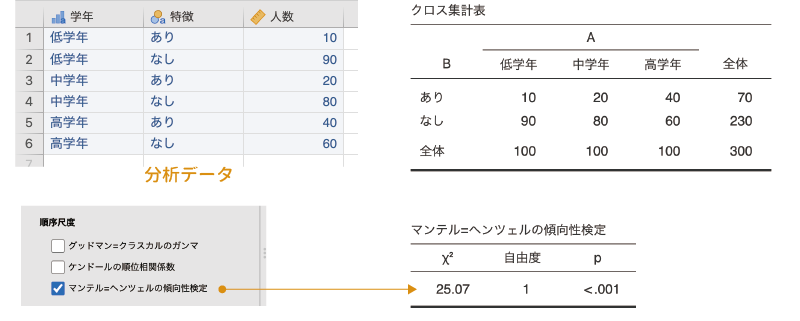

(#fig:frequencies-chisq-mantel)マンテル=ヘンツェルの傾向性検定

### 1.3.6 セル

ここでは，クロス集計表のセル（1つ1つのマス目）に表示する値についての設定を行います（図@ref(fig:frequencies-chisq-cells)）。

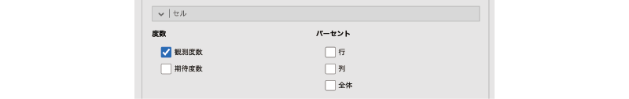

(#fig:frequencies-chisq-cells)セルの設定

- **度数**
  - 観測度数 観測度数を表示します。
  - 期待度数 期待度数を表示します。
- **パーセント**
  - 行 それぞれの行における各セルのパーセントを示します。
  - 列 それぞれの列における各セルのパーセントを示します。
  - 全体 各セルの度数が総度数に占めるパーセントを示します。

「**度数**」にある「観測度数」と「期待度数」は，それぞれ観測度数と期待度数を表示に関する設定項目です。これらの項目にチェックを入れると，チェックした項目の値がクロス集計表に表示されます（図@ref(fig:frequencies-chisq-cells-expected)）。

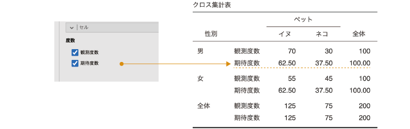

(#fig:frequencies-chisq-cells-expected)期待度数の表示

また，「**パーセント**」にある設定項目は，各セルのパーセント値の表示・非表示についての設定です。「行」にチェックを入れると，それぞれの行ごとに各列の値の占める割合がその行の度数の何%であるかが表示されます。同様に，「列」にチェックを入れると，それぞれの列ごとに各行の値がその列に占める割合が何%であるかが表示されます（図@ref(fig:frequencies-chisq-cells-percentage)）。

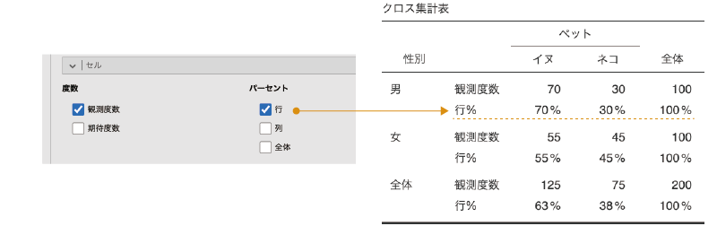

(#fig:frequencies-chisq-cells-percentage)パーセントの表示

「全体」も同様で，この項目にチェックを入れると各セルの度数が総度数の何%を占めるかがクロス集計表に表示されます。

### 1.3.7 グラフ

ここでは，クロス集計表の値を用いたグラフの作成に関する設定を行います（図@ref(fig:frequencies-chisq-plots)）。

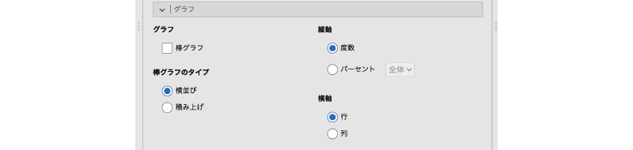

(#fig:frequencies-chisq-plots)グラフの設定

- **グラフ**
  - 棒グラフ 棒グラフを作成します。
- **棒グラフのタイプ**
  - 横並び グループ別に，棒を横並びにして表示します。
  - 積み上げ 各グループの度数を縦に積み上げて表示します。
- **縦軸**
  - 度数 グラフの縦軸に度数を示します。
  - パーセント グラフの縦軸に度数のパーセントを示します。
- **横軸**
  - 行 クロス集計表の行にある変数の値を横軸に配置します。
  - 列 クロス集計表の列にある変数の値を横軸に配置します。

ここの「**グラフ**」にある「棒グラフ」にチェックを入れると，クロス集計表の値を棒グラフとして示すことができます（図@ref(fig:frequencies-chisq-plots-bar)）。

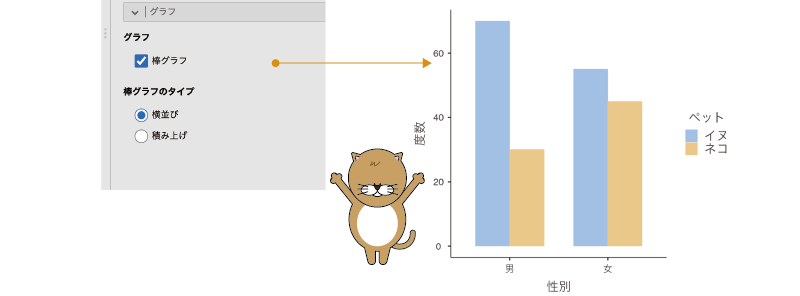

(#fig:frequencies-chisq-plots-bar)棒グラフの表示

ここで作成できる棒グラフは，グループ別に値を横に並べて表示するスタイルと，それぞれのグループの度数を縦に積み上げて表示するスタイルの2種類のスタイルを選択することができます。「**棒グラフのタイプ**」で「横並び」を選択すると，異なるグループの度数が横並びの形で棒グラフに表示されます。これに対し，「積み上げ」を選択すると，異なるグループの度数が縦に積み上げられる形の棒グラフ（積み上げ棒グラフ）が表示されます（図@ref(fig:frequencies-chisq-plots-bar-stack)）。

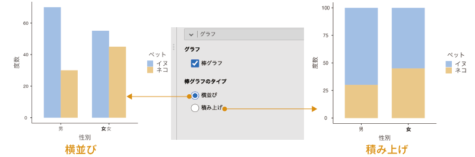

(#fig:frequencies-chisq-plots-bar-stack)棒グラフのスタイル

「**縦軸**」に含まれているのは，グラフの縦軸（数値軸）に示す値についての設定項目です。ここで「度数」を選択すると，グラフの縦軸には度数が示されます。これに対し，「パーセント」を選択した場合には，グラフの縦軸にはその度数が全体または行・列に占めるパーセントの値が縦軸に示されます（図@ref(fig:frequencies-chisq-plots-bar-percentage)）。

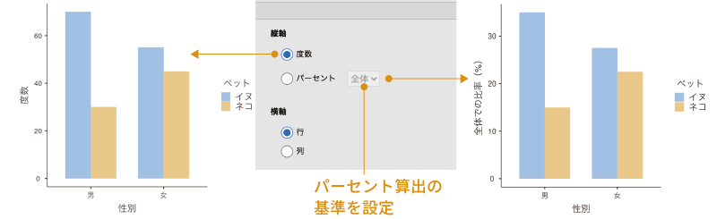

(#fig:frequencies-chisq-plots-bar-percentage)グラフの縦軸の設定

また，全体，行，列のいずれに対するパーセント値を表示させるかは，「パーセント」の横のプルダウンメニューから選択して設定します。ここが「全体」になっている場合には全体におけるパーセント，「行」になっている場合には各行におけるパーセント，「列」になっている場合には各列におけるパーセントになります。

「**横軸**」に含まれているのは，グラフの横軸（項目軸）に用いる値についての設定項目です。ここで「行」を選択すると，グラフの横軸にはクロス集計表の行にある変数の値が用いられます。これに対し，「列」を選択した場合には，グラフの横軸にはクロス集計表の列にある変数の値が用いられます（図@ref(fig:frequencies-chisq-plots-bar-xaxis)）。

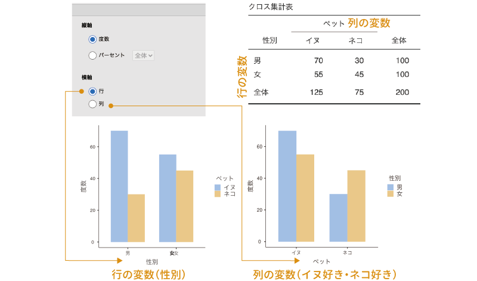

(#fig:frequencies-chisq-plots-bar-xaxis)グラフの横軸の設定

## 1.4 対応あり［マクニマー検定］

無作為に選抜した生徒100人を対象に，本試験用の問題と追試験用の問題の両方を解いてもらい，それぞれ何人が合格基準に達するかを調べたところ表@ref(tab:frequencies-mcnemar-table)の結果が得られたとしましょう。

(#tab:frequencies-mcnemar-table)(#tab:frequencies-mcnemar-table)本試験と追試験での合否の結果

[output not shown]

そしてこの結果から，試験問題の違いによって合格・不合格の程度が異ならない（どちらも難易度が同程度になっている）かどうかを確かめたいとします。この場合，どのように分析すればよいでしょうか。

このデータは，一見すると独立性の検定で分析できそうに見えるのですが，残念ながらそうではありません。なぜなら，このデータでは「本試験」と「追試験」の両方に同じ人のデータが含まれているからです。これはいわゆる「対応あり」のデータで，データ収集方法にそもそも対応があるわけですから，それに対して「独立」かどうかという検定を行っても適切な結果が得られないのです。

このような場合，次にとりあげる*マクニマー検定*と呼ばれる検定が用いられます。

### 1.4.1 考え方

先ほどのクロス集計表は，残念ながらそのままでは分析ができません。このようなデータの場合には，クロス集計表は本試験の合否を行に，追試験の合否を列に配置するような形で作成する必要があります。

そこで，もう一度全員の結果を調べ直し，分析に適した形でクロス集計表を作成し直したところ，表@ref(tab:frequencies-mcnemar-table2)のようになったとします。

(#tab:frequencies-mcnemar-table2)(#tab:frequencies-mcnemar-table2)本試験と追試験での合否結果のクロス集計表

[output not shown]

この表は先ほどの表と似ていますが，先ほどの表は総度数が200だったのに対し，この表は総度数が100で，調査対象の人数と同じになっています。つまり，先ほどの表はデータの対応がまったく考慮されていなかったのに対し，こちらはデータの対応をきちんと考慮した形で集計表が作成されているのです。

次に，本試験と追試験で難易度が同じである場合の期待度数について考えてみましょう。ここでは，考え方についてみるために，それぞれのセルの度数をa〜dで表しています（表@ref(tab:frequencies-mcnemar-table3)）。

(#tab:frequencies-mcnemar-table3)(#tab:frequencies-mcnemar-table3)本試験と追試験での合否結果のクロス集計表

[output not shown]

2つの試験の難易度が同じであれば，本試験で合格できた人は追試験でも合格するはずです。つまり，「a+b」の人数と「a+c」の人数は同じになるはずです。同様に，本試験で合格できなかった人は追試験でも合格できないはずで，その場合には「c+d」と「b+d」の人数も同じになります。

そして，これらの関係を整理すると，合格の度数についての「a+b = a+c」という関係は，結局は「b = c」ということですし，また，不合格の度数についての「c+d = b+d」というのも，結局は「b = c」ということになって，2つの試験で難易度が同じである場合に期待されるのは，「b = c」の状態ということになります。

そこで，マクニマー検定では，観測データにおける右上のセルと左下のセルの値が互いにどれだけずれているかを検定統計量として算出し，そこから2つの試験の難易度に違いがあるといえるかどうかを判断します。

### 1.4.2 分析手順

ここでは，次のサンプルデータ（frequencies_data05.omv）を用いて分析を行いましょう。このデータファイルには次の変数が含まれています（図@ref(fig:frequencies-data05)）。

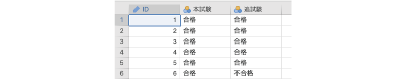

(#fig:frequencies-data05)サンプルデータ

- `ID` 生徒のID
- `本試験` 本試験の合否（合格，不合格）
- `追試験` 追試験の合否（合格，不合格）

ここでは，各生徒の本試験と追試験の結果が入力されたデータファイルを使用しますが，すでに集計済みのデータで分析を行う場合，スプレッドシートには図@ref(fig:frequencies-data06)のような形でデータが入力されている必要があります。

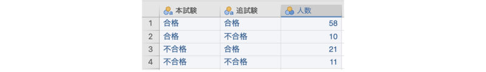

(#fig:frequencies-data06)集計済みデータの入力方法

マクニマー検定を実施するには，分析タブの「

[figure not shown]

度数分析」で「クロス集計表」のところにある「対応あり［マクニマー検定］」を選択します（図@ref(fig:frequencies-mcnemar-menu)）。

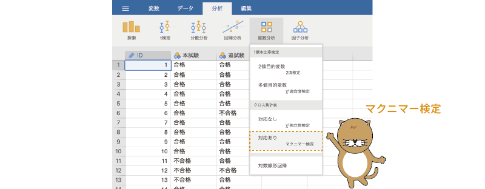

(#fig:frequencies-mcnemar-menu)マクニマー検定の実行

すると，図@ref(fig:frequencies-mcnemar-settings)のような画面が表示されます。

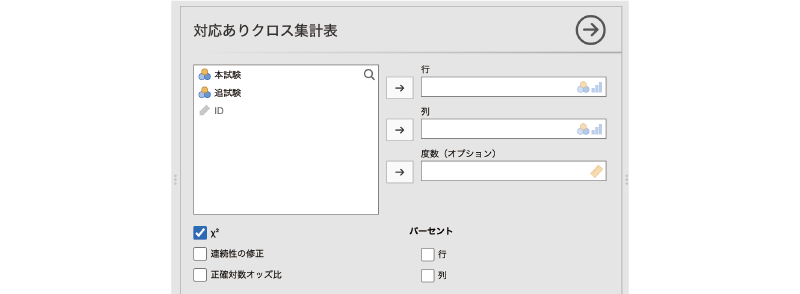

(#fig:frequencies-mcnemar-settings)マクニマー検定の設定画面

- 行 クロス集計表の行に配置する変数を指定します。
- 列 クロス集計表の列に配置する変数を指定します。
- 度数（オプション） 度数が含まれている変数を指定します（オプション）
- $\chi^2$ $\chi^2$値を算出します。
- 連続性の修正 連続性の修正を行った$\chi^2$値を算出します。
- 正確対数オッズ比 対数オッズ比と正確確率検定の結果を表示します。
- **パーセント**
  - 行 各行におけるパーセント値を算出します。
  - 列 各列におけるパーセント値を算出します。

ここでは，「本試験」を「行」に，「追試験」を「列」に設定しましょう。このデータファイルには一人一人の結果が入力されているので，分析の基本設定はこれで終わりです。「度数（オプション）」の設定は必要ありません。集計済みデータで分析をする場合には，度数が入力されている変数を「度数（オプション）」に指定してください（図@ref(fig:frequencies-mcnemar-set-var)）。

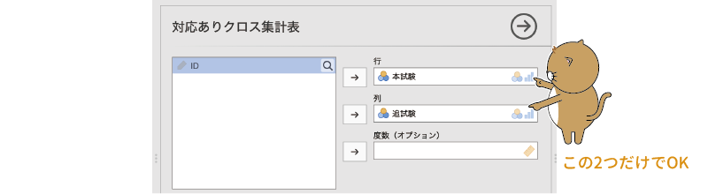

(#fig:frequencies-mcnemar-set-var)マクニマー検定の分析設定

### 1.4.3 分析結果

それでは結果を見てみましょう（図@ref(fig:frequencies-mcnemar-results)）。

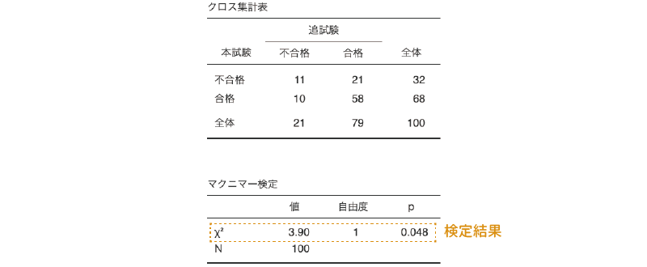

(#fig:frequencies-mcnemar-results)マクニマー検定の結果

結果の表示，および見方は，独立性検定の場合とほぼ同じです。1つ目の表はクロス集計表，2つ目の表が検定結果です。$\chi^2$値の有意確率は5%の有意水準を下回っているので（p = 0.048），検定結果は有意です。つまり，本試験と追試験で難易度（合格・不合格の比率）が異なるということになります。

### 1.4.4 分析オプション

マクニマー検定では利用可能な分析オプションは多くありません。分析に関する設定項目は，検定統計量としてイェーツの修正を行った$\chi^2$を算出する項目と，対数オッズ比を算出するための項目だけです。連続性の修正を行った$\chi^2$は，独立性検定の場合と同じですので説明は省略します。

検定オプションの「正確対数オッズ比」は，正確確率を用いた検定結果を表示します（図@ref(fig:frequencies-mcnemar-logodds)）。この方法を用いて分析した場合に表示される「正確対数オッズ比」の値は，クロス集計表の右上および左下のセルの度数について帰無仮説どおりの場合の比率と観測データにおける比率から算出したオッズ比の対数です。

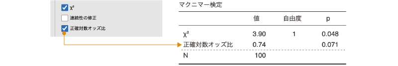

(#fig:frequencies-mcnemar-logodds)対数オッズ比と正確確率検定の結果

また，マクニマー検定はクロス集計表の右上のセルと左下のセルの度数が同じかどうかを検定していますので，考え方としては，この2つのセルの出現比率が1:1になっているかどうかを2項検定するのと同じことになります。この検定における有意確率pの値は，「31人中10人」という結果について2項検定を行った場合の値に一致します。

設定画面右側の「**パーセント**」の項目は，クロス集計表にパーセントを表示するかどうかの設定です。「行」をチェックすれば行ごとのパーセント値が，「列」をチェックすれば列ごとのパーセント値が表示されます。

## 1.5 対数線形回帰

カイ2乗適合度検定は1つの変数についての比率の分析，カイ2乗独立性検定は2つの変数を組み合わせた場合の比率の分析でした。では，3つ以上の場合はどうすればよいでしょうか。jamoviのカイ2乗独立性検定では，3つ目の変数値をグループ変数として層別分析を行うことも可能ですが，その場合，グループ変数と他の変数との関連については見ることができません。

このような，より複雑なデータの場合に使用可能な分析の1つに*対数線形回帰分析*があります。

### 1.5.1 考え方

話を単純にするために，ここでは表@ref(tab:frequencies-loglin-table1)のクロス集計表を例にこの分析の考え方について見てみましょう。これは，独立性検定のところで用いた性別とイヌ派・ネコ派のクロス集計表です。

(#tab:frequencies-loglin-table1)(#tab:frequencies-loglin-table1)性別とイヌ派・ネコ派についてのクロス集計表

[output not shown]

このようなクロス集計表では，各セルの期待度数は，行の度数と列の度数，クロス集計表全体の総度数を用いて次のように求めることができます。

$$\text{期待度数} = \frac{\text{行の度数}\times\text{列の度数}}{\text{総度数}}$$

たとえば，男性でイヌ派のセルの期待度数は，「(100×125)/200 = 62.5」となります。

このとき，この期待度数の式を対数変換すると，この式は次のように表すことができます[^4]。

$$\begin{eqnarray*}
\log(\text{期待度数}) %
& = & \log\left(\frac{\text{行の度数}\times\text{列の度数}}{\text{総度数}}\right)\\
& = & \log(\text{行の度数})+\log(\text{列の度数}) - \log(\text{総度数}) \\
& = & - \log(\text{総度数}) + \log(\text{行の度数})+\log(\text{列の度数})
\end{eqnarray*}$$

各セルの期待度数について考えたとき，この式の「$\log(\text{行の度数})$」と「$\log(\text{列の度数})$」はセルごとに変化しますが，「$-\log(\textsf{総度数})$」の部分は，どのセルにおいても共通ですので，これは回帰式における切片のような役割を担っています。このように考えると，この式はさらに次のような回帰式として表せることになります。

$$\log(\text{期待度数}) = b_0 + b_1\times \text{行の要素} + b_2\times \text{列の要素}$$

一般に，クロス集計表の検定では，行と列が独立であるかどうかについての検定を行いますが，これは行と列の組み合わせによって比率が異なるかどうかを検定しているのと同じです。先ほどの式には行の影響と列の影響しか含まれていませんが，ここに行と列の組み合わせの影響，つまり交互作用による影響を加えると，この式は次のようになります。

$$\log(\text{期待度数}) = b_0 + b_1\times \text{行の要素} + b_2\times \text{列の要素} + b_3\times\text{行と列の交互作用}$$

対数線形回帰分析では，このように対数変換を用いて期待度数（の対数）を目的変数，行・列とその交互作用（の対数）を説明変数とする回帰式を作成し，そしてそれぞれの係数を算出するという形で複雑なクロス集計表についての分析を行います。

### 1.5.2 基本手順

ここでは，独立性検定の層別分析のところで用いたデータ（frequencies_data04.omv）で対数線形回帰分析の実施方法を見ていくことにしましょう。念のため，データファイルに含まれている変数の一覧を示しておきます。

- `性別` 性別（男，女）
- `年齢` 年齢（大人，子供）
- `ケーキ` ケーキの種類
  - ショートケーキ：`ショート`
  - チーズケーキ：`チーズ`
  - チョコレートケーキ：`チョコ`
- `人数` そのケーキを選んだ人数

このデータを用いて，ケーキの選択に性別と年齢がどのように影響しているかをこれから分析していきます。

まず，分析タブの「

[figure not shown]

度数分析」から「対数線形回帰」を選択してください（図@ref(fig:frequencies-loglin-menu)）。

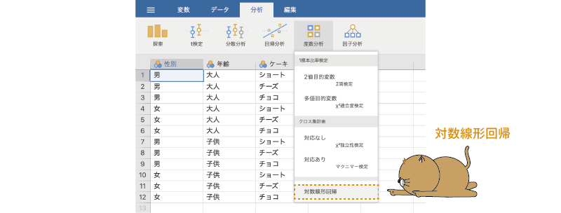

(#fig:frequencies-loglin-menu)対数線形回帰分析の実行

すると，図@ref(fig:frequencies-loglin-settings)のような画面が表示されます。画面の構成は，回帰分析（第@ref(ch-regression)章）のものとよく似ています。

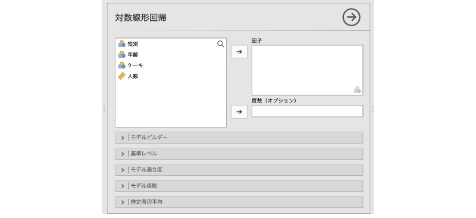

(#fig:frequencies-loglin-settings)対数線形回帰分析の設定画面

- 因子 分析に使用する変数を指定します。
- 度数（オプション） 度数が入力されている変数を指定します（オプション）

[figure not shown]

- | モデルビルダー 交互作用を含むモデルの作成や複数モデルの比較を行います。

[figure not shown]

- | 基準レベル 比較基準として用いる水準値を指定します。

[figure not shown]

- | モデル適合度 モデル適合度に関する設定を行います。

[figure not shown]

- | モデル係数 モデル係数に関する設定を行います。

[figure not shown]

- | 推定周辺平均 各主効果の周辺平均値（回帰モデルによる推定値）に関する設定を行います。

基本的な分析は，分析に使用する変数をすべて「因子」の部分に移動するだけです。また，今回のデータファイルのように度数集計済みのデータで分析する場合には，度数が入力されている変数（ここでは「人数」）を「度数（オプション）」の欄に指定します（図@ref(fig:frequencies-loglin-setvar)）。

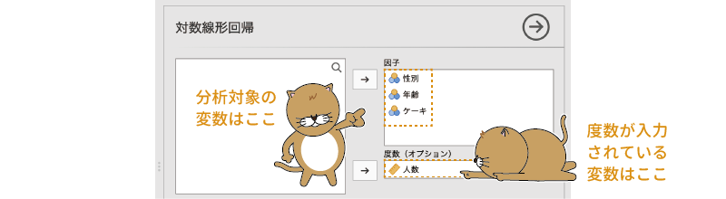

(#fig:frequencies-loglin-setvar)対数線形回帰分析の設定

実際にはもう少しいろいろと設定が必要なのですが，ひとまずこれで分析の基本設定はおしまいです。それでは結果を見てみましょう。

### 1.5.3 分析結果

対数線形モデルの結果は，図@ref(fig:frequencies-loglin-results)のような形で表示されます。

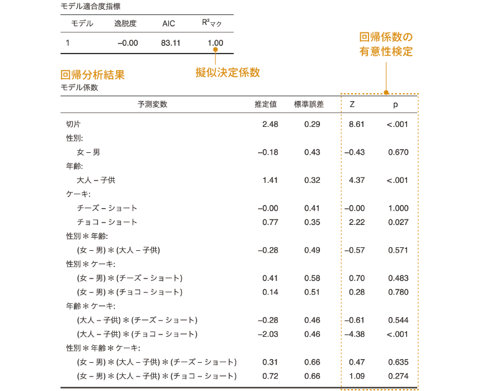

(#fig:frequencies-loglin-results)対数線形回帰分析の結果

分析の手順が簡単だった割に，随分と複雑な結果に見えます。この結果の表について，1つずつみていきましょう。

まず，結果の1つ目の表は，モデルの適合度に関する指標です。この表には，ロジスティック回帰分析の場合と同様に逸脱度とAIC，擬似決定係数が示されています。ただ，この分析結果では，じつはデータは完全に説明されていて，モデルとデータの残差はありません。このように実際の観測データを完全に説明したモデルは*飽和モデル*と呼ばれます。そのため，逸脱度は0になっており，マクファデンの擬似決定係数も1.00になっています。

そしてその下の表が回帰係数の推定値ですが，この表はとても複雑です。対数線形モデルでは，分析で説明変数として使用する変数はすべて名義型変数であるため，それらはすべて*ダミーコード化*されています。そして，その変数値の1つを基準として比較した結果がここにまとめられているために，このように複雑な表になっているのです。

また，今回のデータにおける「ケーキ」のように，3つ以上のカテゴリーがある変数が含まれている場合，このダミーコード化の際にどの変数値を基準としたかによって，この表に示される係数やその係数が有意かどうかが大きく変化します。

そのため，実際にはこのままこの分析結果を解釈することはできません。データに含まれる関係の理解のためには，ここからもう少し分析モデルに修正を加えていく必要があります。

### 1.5.4 モデルビルダー

ここからは分析モデルの修正についてみていきましょう。この分析のモデルを修正するには，

[figure not shown]

| モデルビルダーを使用します（図@ref(fig:frequencies-loglin-modelbuilder)）。

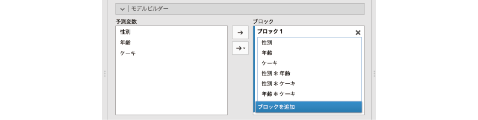

(#fig:frequencies-loglin-modelbuilder)モデルビルダー

分析の初期設定では，このモデルビルダーの「ブロック」には分析に使用する3つの変数（「性別」，「年齢」，「ケーキ」）の主効果と，これらの1次の交互作用，2次の交互作用のすべてが含まれています。これは先ほど結果の見方のところで説明したように「飽和モデル」と呼ばれるモデルで，このモデルでは観測データを完全に説明することが可能です。

飽和モデルはデータを完全に説明できる反面，構造が複雑になってしまうため，理解することが困難になりがちです。データ解析の目的は，そのデータに含まれる変数間の関係を解き明かし，理解することにあるわけですから，それでは困ります。そこで，この飽和モデルから結果に大きな影響を与えていない主効果や交互作用を取り除き，モデルを単純化していくことにします。

まずは，ブロックを追加をクリックして，新たなブロックを作成しましょう。そして，その新しく作成したブロックに，飽和モデルに含まれる項目のうち，もっとも複雑な項目である3変数の交互作用（2次の交互作用）「性別＊年齢＊ケーキ」を「**ブロック1**」から「**ブロック2**」にドラッグして移動します（図@ref(fig:frequencies-loglin-modelbuilder-2way-interaction)）。

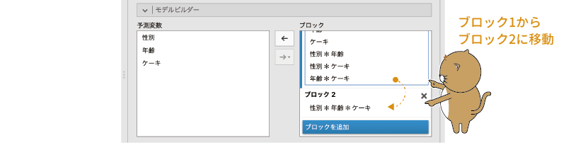

(#fig:frequencies-loglin-modelbuilder-2way-interaction)2次の交互作用をブロック2に移動

この状態で一度結果を見てみましょう。見る必要があるのは，「モデル適合度指標」と「モデルの比較」の部分です（図@ref(fig:frequencies-loglin-modelbuilder-comparison)）。

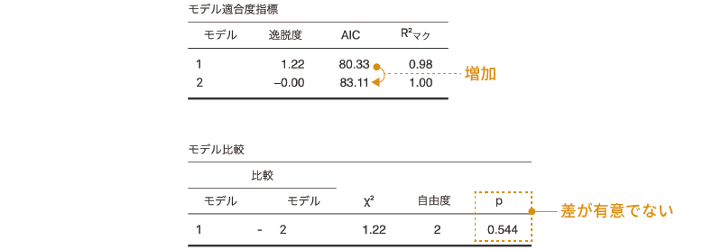

(#fig:frequencies-loglin-modelbuilder-comparison)モデルの比較

この結果を見てみると，すべての項目を含む飽和モデル（モデル2）と，そこから2次の交互作用を取り除いたモデル（モデル1）では，飽和モデルの方がAICの値が大きく，また，この2つのモデルで適合度に有意な差はないことがわかります。これはつまり，2次の交互作用はこのデータを説明するうえで余分というか過剰な項目であるということです。そこで，この交互作用は分析モデルから除外してしまいましょう。

モデルビルダーの「**ブロック2**」にある「性別＊年齢＊ケーキ」を選択し，「

[figure not shown]

」をクリックして分析モデルから除外します（図@ref(fig:frequencies-loglin-modelbuilder-2way-removed)）。

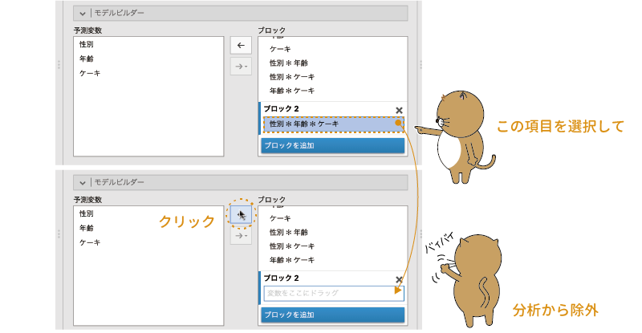

(#fig:frequencies-loglin-modelbuilder-2way-removed)分析モデルから交互作用を除外

今度は1次の交互作用（2つの変数間の交互作用）についても見ていきましょう。1次の交互作用は，「性別＊年齢」，「性別＊ケーキ」，「年齢＊ケーキ」の3つですが，このうち，「性別＊ケーキ」と「年齢＊ケーキ」の交互作用は，それぞれ「性別によってケーキの選択比率が違う」，「大人か子供かによってケーキの選択比率が違う」という意味ですが，「性別＊年齢」の交互作用は「性別によって大人と子供の比率が違う」という意味で，これは今回の分析における関心とは関連がありません。また，今回のデータは大人も子供も男女同数ですので，この分析においては意味がない項目です。

そこで，今度はこの「性別＊年齢」を「**ブロック2**」に入れて，これを除外した場合とそうでない場合とでモデルの適合度がどう変化するかを見てみましょう（図@ref(fig:frequencies-loglin-modelbuilder-compare2)）。

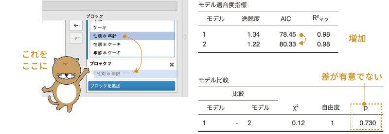

(#fig:frequencies-loglin-modelbuilder-compare2)再度モデルを比較

すると，この場合も「性別＊年齢」を除外したモデルの方がAICの値が小さく，相対的な適合度が高いことが示されました。また，2つのモデルで適合度に有意な差はありません。そこで，この交互作用もモデルから除外してしまいましょう。

1次の交互作用はあと2つ残っています。この2つはどちらも分析の関心と関連があるものですが，念のためモデルへの影響度を見ておきましょう。まずは「年齢＊ケーキ」について，先ほどと同様にして結果を見てみましょう。すると，この場合の結果は図@ref(fig:frequencies-loglin-modelbuilder-comparison3)のようになります。

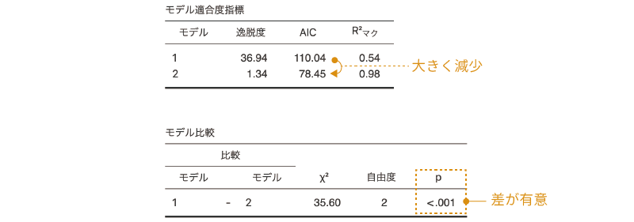

(#fig:frequencies-loglin-modelbuilder-comparison3)年齢とケーキの交互作用についての検討

この結果では，モデルに「年齢＊ケーキ」の交互作用を加えることによって大きくAICの値が減少しており，また，これを入れたモデルと除外したモデルでは，適合度に有意な差があることがわかります。つまり，この交互作用はモデルから除外すべきではありません。

同様に，「性別＊ケーキ」についても見てみましょう。この場合は図@ref(fig:frequencies-loglin-modelbuilder-comparison4)の結果が得られます。

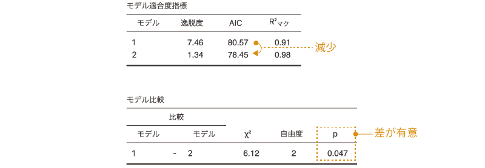

(#fig:frequencies-loglin-modelbuilder-comparison4)性別とケーキの交互作用についての検討

この結果から，「性別＊ケーキ」の交互作用もモデルから除外しない方が良さそうです。

さて，次は「性別」，「年齢」，「ケーキ」それぞれの主効果についてですが，ここまでの結果では「性別＊ケーキ」と「年齢＊ケーキ」がモデルに含まれており，そしてこの3つの変数はこの交互作用の少なくとも1つに関係していますので，これらはモデルから除外することができません。そのため，ここでモデルの修正はおしまいということになります。

このようなモデル修正の結果，性別，年齢，ケーキの選択の各主効果と，性別×ケーキ，年齢×ケーキの交互作用から結果を説明できそうだということがわかりました。なお，ここでの分析の関心は，性別によって選択するケーキの比率に違いがあるか，年齢によって選択するケーキの比率に違いがあるかということでしょうから，これらのうち，とくに交互作用について中心的に見ていくことになります。

### 1.5.5 基準レベル

モデルの修正によって分析結果は単純化されたのですが，それでもまだ，「モデル係数」の結果の表の解釈には注意が必要です。基本設定のみの分析結果のところでも説明したように，この係数の値は，各変数のどの値を基準に考えるかによって大きく変わるからです。そのため，分析結果について検討するには，各変数における基準値をよく確認し，必要に応じて基準値を変更しなくてはなりません。

設定画面の

[figure not shown]

| 基準レベルを展開すると，初期状態では図@ref(fig:frequencies-loglin-referencelevels)のようになっているはずです。

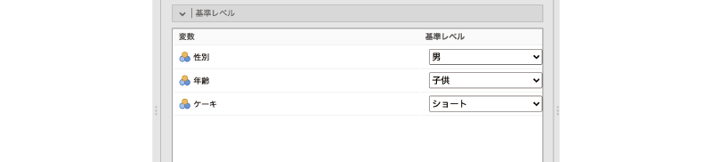

(#fig:frequencies-loglin-referencelevels)基準レベルの設定

そして，この状態での「モデル係数」の表は，図@ref(fig:frequencies-loglin-referencelevels-result1)のようになっています。

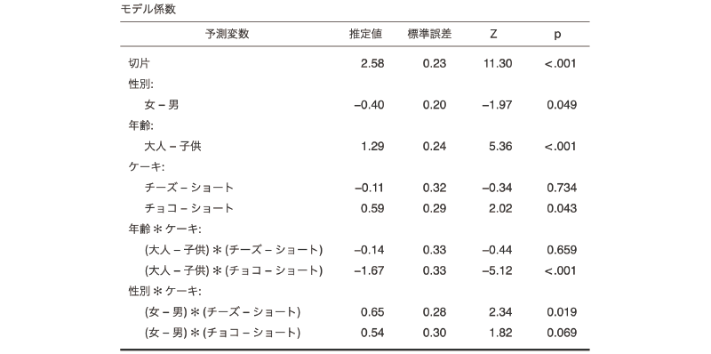

(#fig:frequencies-loglin-referencelevels-result1)対数線形回帰分析の結果

この場合，結果の表では，「男」の「子供」で「ショート（ケーキ）」を選択した度数が入力されているセルが基準となっており，切片の値は，その基準セルについてこの分析モデルから推定される度数の対数値になっています。つまり，切片の値「2.58」を指数変換したもの（$e^{\textsf{2.58}} = \textsf{13.2}$）が，「男性・子供・ショートケーキ」のセルの推定度数ということです。

そして，その下の「性別：」の部分には「女 - 男（男性と比較した場合の女性の値）」についての推定値があり，そしてこの値のpは0.049で有意になっていますが，これは，男性に比べて女性の度数が有意に小さいという意味ではなく，「**男性**・子供・ショートケーキ」のセルに比べて「**女性**・子供・ショートケーキ」のセルの度数が有意に小さいという意味です。この場合，「女性・子供・ショートケーキ」の推定度数は，切片の2.58に$-\textsf{0.40}$を加えた値を指数変換したもの（$e^{\textsf{2.58}+(-\textsf{0.40})} = \textsf{8.85}$）になります。

同様に，その下の「年齢：」の部分にある「大人 - 子供」は，子供に比べて大人の度数が大きいということではなく，「男性・**子供**・ショートケーキ」のセルに比べて「男性・**大人**・ショートケーキ」の度数が有意に大きいという意味です。そしてこの係数から推定されるのは「男性・大人・ショートケーキ」の度数です。もし，「**女**・**大人**・ショートケーキ」の度数について推定したければ，そのセルは切片（男性・子供・ショートケーキ）から男性を女性に，子供を大人に変更した場合ということになるので，「女 - 男」の係数と「大人 - 子供」の係数の両方を切片に加えたもの（2.58 + ($-\textsf{0.40}$) + 1.29 = 3.47）を指数変換した値（$e^{\textsf{3.47}} = \textsf{32.14}$）がその推定値ということになるのです。

つまり，この結果の表に示されている主効果や交互作用の係数は，図@ref(fig:frequencies-loglin-results-interpretation)の関係について示したものなのです。

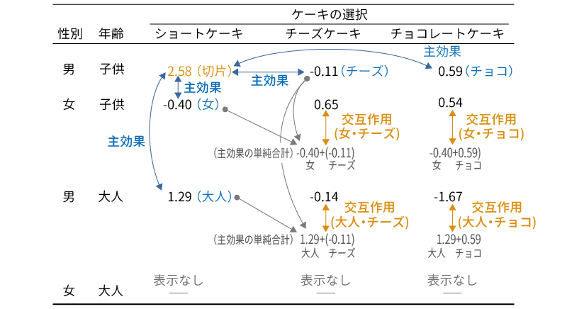

(#fig:frequencies-loglin-results-interpretation)対数線形回帰分析の係数とクロス集計表の関係

このうち，「ショートケーキを選ぶ人では，大人の男性より男児の方が人数が少ない」の部分については注意が必要です。今回のデータファイルでは子供の人数は大人の半分であり，これはあたりまえの結果だからです。ですので，この部分に何か特別な意味があると勘違いしないようにしましょう。

また，ここに挙げた結果に検討したい部分が含まれていない場合には，

[figure not shown]

| 基準レベルで基準レベルを適切に変更し，そこで得られた結果を確認しなくてはなりません。

このように，対数線形回帰分析は結果の解釈が非常に複雑になってしまうのが難点です。

### 1.5.6 モデル適合度

設定画面の

[figure not shown]

| モデル適合度には，図@ref(fig:frequencies-loglin-model-fit)の項目が含まれています。

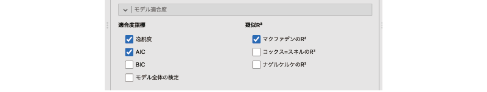

(#fig:frequencies-loglin-model-fit)適合度指標の設定

- **Fit Measures**（適合度指標）
  - 逸脱度 モデルの残差逸脱度を算出します。
  - AIC 赤池情報量規準を算出します。
  - BIC ベイズ情報量規準を算出します。
  - モデル全体の検定 $\chi^{2}$を用いてモデル全体の有意性検定を行います。
- **擬似R²** モデルのあてはまりの程度を標準化した値を算出します。
  - マクファデンのR² マクファデンの擬似決定係数を算出します。
  - コックス=スネルのR² コックス=スネルの擬似決定係数を算出します。
  - ナゲルケルケのR² ナゲルケルケの擬似決定係数を算出します。

これらの項目は2項ロジスティック回帰（第@ref(ch-regression)章 @ref(sec-regression-binomial)）のモデルの適合度と同じものですので，ここでは説明を省略します。

### 1.5.7 モデル係数

設定画面の

[figure not shown]

| モデル係数には，次の項目が含まれています（図@ref(fig:frequencies-loglin-coeff)）。

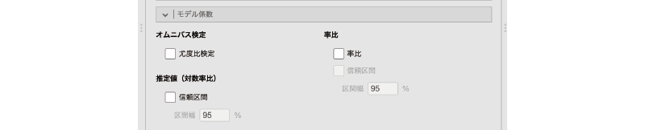

(#fig:frequencies-loglin-coeff)モデル係数の設定

- **オムニバス検定**
  - 尤度比検定 モデル全体の適合度について尤度比検定を行います。
- **推定値（対数率比）**
  - 信頼区間 対数率比の信頼区間を算出します。
- **率比**
  - 率比 率比を算出します。
  - 信頼区間 率比の信頼区間を算出します。

尤度比を用いたオムニバス検定については，ロジスティック回帰の場合と同じですのでここでは説明を省略します。

それ以外の数値についても，基本はロジスティック回帰分析の場合と同じですが，ここで示されるのは*オッズ比*ではなく，各セルの比率に基づく*率比*（比率の比）である点には注意してください。対数線形モデルでは，回帰モデルの各係数は，*対数オッズ比*ではなく，比率の比の対数になっているからです。ただ，このように回帰係数の値の性質が少し異なるというだけで，表示される結果の見方や考え方はロジスティック回帰分析の場合と同じです。「**推定値（対数率比）**」の「信頼区間」にチェックを入れれば，回帰係数の信頼区間が算出されますし，「**率比**」の部分の設定を行えば，回帰係数を指数変換した値やその信頼区間を表示させることができます。

### 1.5.8 推定周辺平均

設定画面の

[figure not shown]

| 推定周辺平均には，次の項目が含まれています。

- 周辺平均値 周辺平均値の算出対象を指定します
- **全般オプション**
  - 均等重みづけ
  - 信頼区間 周辺平均値の信頼区間を算出します
- **出力**
  - 周辺平均値のグラフ
  - 周辺平均値の表

[figure not shown]

| 推定周辺平均の設定項目やその使用方法は，第@ref(ch-regression)章の線形回帰のところで説明したのと同じですので，詳細についてはここでは説明は省略します（線形回帰の「推定周辺平均」を参照）。

なお，このオプションで表示される「推定周辺平均」は，回帰モデルの予測値，つまりは度数の推定値ですので，その点だけ注意してください。

[^1]: 2項分布の計算式やその具体的な計算方法については本書では省略します。統計法の教科書などを参照してください。
[^2]: 分布の形状を決める値のことです。2項分布では試行数nと確率pが，正規分布では平均値と分散（または標準偏差）がパラメータとなります。
[^3]: Kass, R. E. & Raftery, A. E. (1995). Bayes Factors. *Journal of the American Statistical Association, 90*, 773–795. doi:10.1080/01621459.1995.10476572
[^4]: 掛け算の式を対数変換した場合，その式は元の項目の対数同士の足し算として，割り算の式を対数変換した場合，その式は元の項目の対数同士の引き算として表すこができます。多変量解析の中でしばしば対数変換が行われるのは，このように掛け算を足し算に，割り算を引き算にできることで計算が単純になるということが理由の1つにあるのです。